# EPSI Theta Analysis

Trevor James Swanson

April 28, 2020

# Background

Kotov et al. (2017) and Forbush et al. (2018) tested and replicated a joint hierarchical factor model with the EPSI and IDAS-II in samples of participants with a *DSM-5* ED. In the sample used for the present analysis (from Forbush et al. 2018) recovery outcomes were assessed twice after an initial baseline session: (a) at a 6-month follow-up, and (b) a 12-month follow-up.

Dr. Song used the multidimensional IRT implemented in the CAT app to estimate 3 Theta values for the EPSI in this sample. **The goal of this analysis is to evaluate whether the EPSI Theta parameters are useful in predicting recovery outcomes.** We plan on conducting further analyses after estimating Theta values for the IDAS-II, as well as to perform these analyses on an additional sample.

The data consist of $N = 247$ participants, and the outcomes of interest span 4 categories (1 = Poor, 2 = Intermediate, 3 = Good, 4 = Excellent). The categories are based on criteria related to BMI and the number of binge-eating $(BE)$ and compensatory episodes $(CE)$ that occurred in the past 3 weeks. Specifically:

- **Poor outcome** was defined as: $BMI < 18.5\$ or $\ BE\,\&\,CE \geq 12$
- **Intermediate outcome** was defined as: $BMI \geq 18.5\$ and $\ BE\,\&\,CE < 12$
- **Good outcome** was defined as: $BMI \geq 20\$ and $\ BE\,\&\,CE = 0$
- **Excellent outcome** was the same as Good, except that EPSI Body Dissatisfaction scores must also be $< 1\ SD$ above community norms.

Given the imbalanced nature of the sample, I tested different models treating the outcomes as either polytomous or binary (collapsing the Intermediate, Good, and Excellent categories into a ‘Marginal’ category). It is important to note that more than half the data $(\sim 57\%)$ is missing for the 12-month follow-up. I focus on the polytomous models in the first section, and the binomial models in the second section. In each section, I start by presenting the model(s) fit with listwise deletion, and then re-evaluate the models after imputing missing values. I take the following approach in each analysis:

1. I begin by fitting the hypothesized model (where the Theta values predict the outcome), then use a likelihood ratio test (LRT) to determine whether this model outperforms an intercept-only model.
2. I display the coefficients for the hypothesized model, along with their associated standard errors and probability values. Interpretation is only provided if the LRT indicates that the hypothesized model predicts the outcome significantly better than the intercept model.

# Polytomous Outcome

The 4 outcome categories along with their empirical frequencies at the 6-month and 12-month assessments are displayed below.

| Outcome | 6 month Frequency | 6 month Percent | 12 month Frequency | 12 month Percent |
| --- | --- | --- | --- | --- |
| Poor | 22 | 8.9% | 82 | 33.2% |
| Intermediate | 132 | 53.4% | 19 | 7.7% |
| Good | 6 | 2.4% | 1 | 0.4% |
| Excellent | 9 | 3.6% | 4 | 1.6% |
| Missing | 78 | 31.6% | 141 | 57.1% |

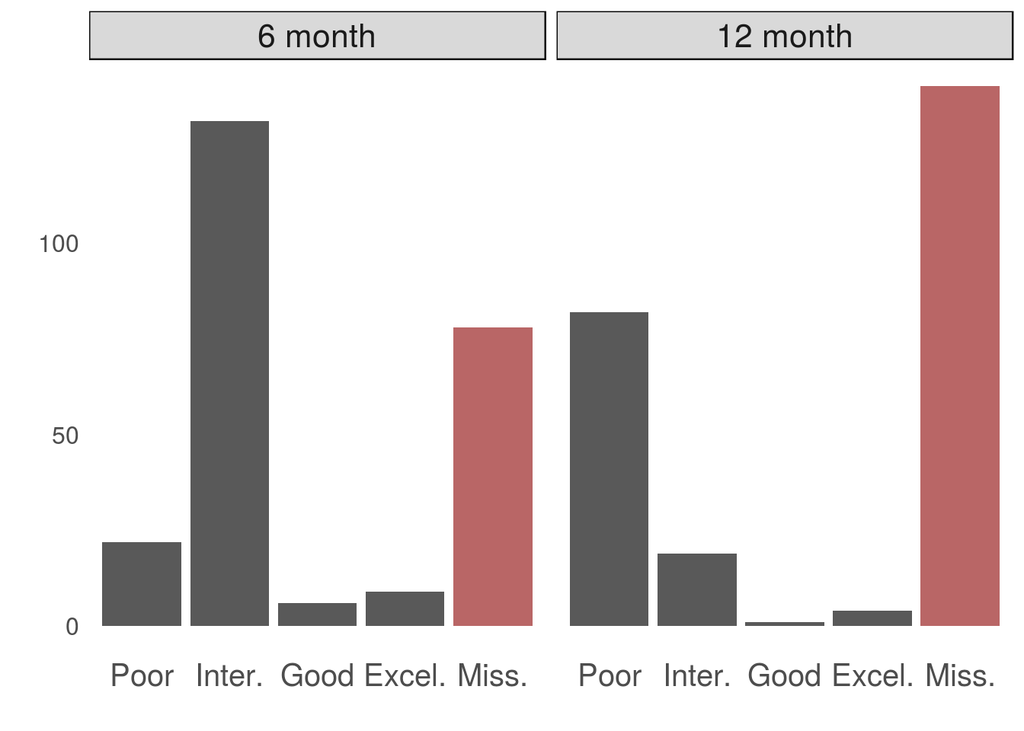

The categories are highly imbalanced at each time point and have a high degree of missingness. For each timepoint I use two separate analyses—a *proportional odds logistic regression* (designed for ordinal outcomes), and a *multinomial regression*. I will begin by focusing on the 6-month outcome, and then will present the same analyses for the 12-month outcome.